# Star Trek script analysis

Criticisms of Discovery aside, here’s an objective (imo) look at the raw scripts. This analysis covers all canon Trek series from TOS to DIS (S1 only.) Non-Discovery data is available on Kaggle: https://www.kaggle.com/gjbroughton/start-trek-scripts which is originally sourced from chakoteya.net. Discovery scripts were also pulled from chakoteya.net but currently only season 1 is available.

```r
library(tidyverse)
library(jsonlite)
library(rvest)
library(koRpus)
library(koRpus.lang.en)
```

First, the non-Discovery series imported from the Kaggle dataset

```r
### import scripts
st_lines <- read_json("X:\\Documents\\trek_scripts\\all_series_lines.json")

### initialise some vectors ###

# to count the number of words in each episode
st_n_words <- c()
# to store the episode number
st_names <- c()
# to store the length of each word in an episode
st_word_length <- list()
```

The json file is very well organized

```r
## st_lines[["series"]][[episode number]]
st_lines[["TNG"]][[2]] %>% unlist(use.names = FALSE) %>% head()
```

```
[1] "Report."
[2] "Are you certain? Yes, of course you are."
[3] "Picard here."
[4] "But there were eighty people on that ship, Number One."
[5] "Give me a theory, Doctor. Anything. Madness? Mass hysteria? Delusion?"
[6] "All right. Let's bring the away team back. Set the transporterto maximum decontamination, and then full examination and observationwhen they're here."
```

Iterate over each episode to clean up and pull the information mentioned above

```r
for(series in seq(1, length(st_lines))) {
  for (episode in seq(1, length(st_lines[[series]]))) {
    ## get the unique words in each episode
    words <-
      st_lines[[series]][[episode]] %>%
      unlist(use.names = FALSE) %>%
      ## somewhat crude clean-up to remove punctuation
      lapply(function(x) {
        gsub("\\.|,|!|\\?", "", x)
      }) %>% lapply(str_split, " ") %>%
      unlist()
    unique_words <- words %>% unique()
    ## get the season and episode number
    st_names[length(st_names) + 1] <-
      paste0(names(st_lines[series]), "_",
             names(st_lines[[series]][episode]))
    ## count the number of unique words per episode
    st_n_words[length(st_n_words) + 1] <-
      unique_words %>% length()
    ## get the length of each (unique) word
    st_word_length[[length(st_word_length) + 1]] <-
      unique_words %>% lapply(nchar) %>% unlist()
  }
}
```

Put the three vectors together and make a neat table

```r
st_words <- tibble("episode"      = st_names,
                   "unique_words" = st_n_words,
                   "word_lengths" = st_word_length)
head(st_words)
```

| episode | unique_words | word_lengths |
| --- | --- | --- |
| ENT_episode 0 | 2272 |  |
| ENT_episode 1 | 1494 |  |
| ENT_episode 2 | 1372 |  |
| ENT_episode 3 | 1467 |  |
| ENT_episode 4 | 1249 |  |
| ENT_episode 5 | 1187 |  |

```r
dim(st_words)
```

```
[1] 708   3
```

Now the same for Discovery episodes pulled manually (from a URL table created with import.io)

```r
std <- read_csv("X:\\Documents\\trek_scripts\\std.csv")
head(std)
```

| Episode Name | Series/episode | Release date |
| --- | --- | --- |
| http://www.chakoteya.net/STDisco17/101.html | 101 | 24-Sep-17 |
| http://www.chakoteya.net/STDisco17/102.html | 102 | 27-Sep-17 |
| http://www.chakoteya.net/STDisco17/103.html | 103 | 1-Oct-17 |
| http://www.chakoteya.net/STDisco17/104.html | 104 | 8-Oct-17 |
| http://www.chakoteya.net/STDisco17/105.html | 105 | 15-Oct-17 |
| http://www.chakoteya.net/STDisco17/106.html | 106 | 22-Oct-17 |

```r
std_n_words <- c()
std_names <- c()
std_word_length <- list()
```

The Discovery scripts are not as clean as those from the json file and will require a bit more finagling

```r
## read the html
read_html("http://www.chakoteya.net/STDisco17/101.html") %>%
  ## parse nodes
  html_nodes(
    "body > div:nth-child(2) > center:nth-child(1) > table:nth-child(1) > tbody:nth-child(1) > tr:nth-child(1) > td:nth-child(1)") %>%
  ## parse text
  html_text() %>% substr(1, 500)
```

```
[1] "\r\n[Klingon ship]\r\n\r\nT'KUVMA: They are coming. Atom by atom they will coil around us and take all that we \r\nare. There is only one way to confront this threat. By reuniting the twenty four \r\nwarring houses of our empire. We have forgotten the unforgettable, the last to \r\nunify our tr…
```

```r
## read the html
(read_html("http://www.chakoteya.net/STDisco17/101.html") %>%
  ## parse nodes
  html_nodes(
    "body > div:nth-child(2) > center:nth-child(1) > table:nth-child(1) > tbody:nth-child(1) > tr:nth-child(1) > td:nth-child(1)") %>%
  ## parse text
  html_text() %>%
    str_extract_all("\n.*:.*") %>%
    lapply(function(x) {
      gsub("\\.|,|!|\\?| $|^.*: |\n|\\[|\\]|\\(|\\)|\"", "", x)
    }))[[1]][1:5]
```

```
[1] "They are coming Atom by atom they will coil around us and take all that we"
[2] "We come in peace That's why we're here Isn't that the whole idea of Starfleet"
[3] "Hey I taught you that"
[4] "You don't trust me Captain"
[5] "I trust you with my life Commander Burnham but it doesn't change the fact that you're lost"
```

That’s better.

Much the same processes for Discovery scripts, but an additional step to parse the page with `html_nodes` and a little more cleanup

```r
 for (episode in seq(1, nrow(std))) {
   script <-
     read_html(std$`Episode Name`[episode]) %>%
     html_nodes(
       "body > div:nth-child(2) > center:nth-child(1) > table:nth-child(1) > tbody:nth-child(1) > tr:nth-child(1) > td:nth-child(1)")
   words <-
     script[[1]] %>% html_text() %>%
    str_extract_all("\n.*:.*") %>%
    lapply(function(x) {
      gsub("\\.|,|!|\\?| $|^.*: |\n|\\[|\\]|\\(|\\)|\"", "", x)
    }) %>% lapply(str_split, " ") %>%
    unlist()

  std_n_words[length(std_n_words) + 1] <-
    words %>% unique() %>% length()

  std_names[length(std_names) + 1] <-
     paste0("DIS", "_", std$`Series/episode`[episode])

  std_word_length[[length(std_word_length) + 1]] <-
    words %>% unique() %>% lapply(nchar) %>% unlist()
}
```

Merge the Discovery data with the previous table

```r
st_all_words <-
  bind_rows(st_words, tibble(
    "episode" = std_names,
    "unique_words" = std_n_words,
    "word_lengths" = std_word_length
  )) %>% mutate(series = substr(episode, start = 1, stop = 3))
dim(st_all_words)
```

```
[1] 723   4
```

At this point I can look at the unique words per episode per series

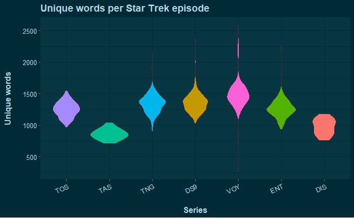

```r
st_all_words %>% ggplot(aes(
  x = factor(series,
             levels = c("TOS", "TAS", "TNG", "DS9",
                        "VOY", "ENT", "DIS")),
  y = unique_words)) + geom_violin(aes(fill = series)) +
  labs(x = "\nSeries", y = "Unique words\n", fill = "",
       title = "Unique words per Star Trek episode") +
  guides(fill = FALSE) +
  theme_solarized_dark(f_color = "lightblue", f_angle = 25)
```

Almost there, but the scripts are organized such that two-part episodes have one script file. I suspect those two-parters are being presented as outliers, so I’ll go ahead and remove them and re-plot the data.

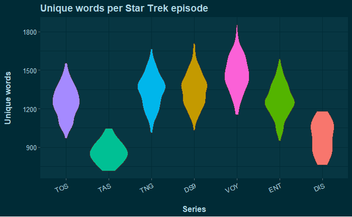

```r
st_all_words %>% group_by(series) %>%
  ## calculate interquartile range
  mutate(IQR = IQR(unique_words),
         ## calculate upper and lower quartile
         q1 = quantile(unique_words,
                       probs = 0.25),
         q2 = quantile(unique_words,
                       probs = 0.75),
         ## calculate tukey's quartile bounds
         qup = q2 + (1.5 * IQR),
         qlow = q1 -(1.5 * IQR)) %>%
  ## filter data
  filter(unique_words >= qlow,
         unique_words <= qup) %>% ggplot(aes(
  x = factor(series,
             levels = c("TOS", "TAS", "TNG", "DS9",
                        "VOY", "ENT", "DIS")),
  y = unique_words)) + geom_violin(aes(fill = series)) +
  labs(x = "\nSeries", y = "Unique words\n",
       title = "Unique words per Star Trek episode") +
  guides(fill = FALSE) +
  theme_solarized_dark(f_color = "lightblue", f_angle = 25)
```

Now to look at the mean word length per episode per series

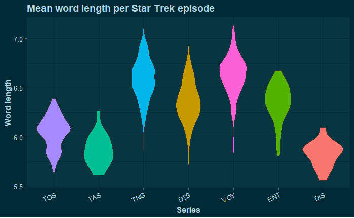

```r
st_all_words %>% mutate(length_mean = lapply(word_lengths, mean,
                                             na.rm = TRUE) %>% unlist()) %>%
  ggplot(aes(
  x = factor(series,
             levels = c("TOS", "TAS", "TNG", "DS9",
                        "VOY", "ENT", "DIS")),
  y = length_mean)) +
  geom_violin(aes(fill = series)) +
  labs(x = "Series", y = "Word length",
       title = "Mean word length per Star Trek episode") +
  guides(fill = FALSE) +
  theme_solarized_dark(f_color = "lightblue", f_angle = 25)
```

It’s not as messy as the previous chart, but it can still be cleaned up a little I think

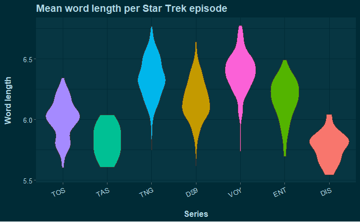

```r
st_words_q <-
  st_all_words %>% mutate(series = substr(episode, start = 1, stop = 3),
                      iqr = lapply(word_lengths, IQR) %>% unlist(),
                      q1_lengths = lapply(word_lengths, quantile, 0.25) %>% unlist(),
                      q2_lengths = lapply(word_lengths, quantile, 0.75) %>% unlist(),
                      qup = q2_lengths + (1.5 * iqr),
                      qlow = q1_lengths -(1.5 * iqr))

st_words_no_out <-
st_words_q %>%
    mutate(filtered_lengths     = lapply(word_lengths,
                                         function(x){
                                             (x %>% unlist())[x %>% unlist() >= qlow &
                                                                  x %>% unlist() <= qup]}),
           filtered_length_mean = lapply(filtered_lengths, mean, na.rm = TRUE) %>%
               unlist()) %>% suppressWarnings()

st_words_no_out %>%
  ggplot(aes(
  x = factor(series,
             levels = c("TOS", "TAS", "TNG", "DS9",
                        "VOY", "ENT", "DIS")),
  y = filtered_length_mean)) +
  geom_violin(aes(fill = series)) +
  labs(x = "\nSeries", y = "Word length\n", fill = "",
       title = "Mean word length per Star Trek episode") +
  guides(fill = FALSE) +
  theme_solarized_dark(f_color = "lightblue", f_angle = 25)
```

Run [TreeTagger](https://cis.uni-muenchen.de/~schmid/tools/TreeTagger/) on Discovery scripts

```r
std_tags <- list()
std_names <- c()

for (episode in seq(1, nrow(std))) {
  script <-
    read_html(std$`Episode Name`[episode]) %>% html_nodes(
      "body > div:nth-child(2) > center:nth-child(1) > table:nth-child(1) > tbody:nth-child(1) > tr:nth-child(1) > td:nth-child(1)"
    )
  script[[1]] %>% html_text() %>%
    str_extract_all("\n.*:.*") %>%
    lapply(function(x) {
      gsub("\\.|,|!|\\?| $|^.*: |\n|\\[|\\]|\\(|\\)|\"", "", x)
    }) %>% lapply(str_split, " ") %>%
    unlist() %>% write_lines("std_ep.txt")

  std_tag <- treetag(
    "std_ep.txt",
    treetagger = "manual",
    lang = "en",
    TT.options = list(
      path = "C:/TreeTagger/",
      preset = "en"
    )
  )

  std_names[length(std_names) + 1] <-
    paste0("DIS", "_", std$`Series/episode`[episode])

  std_tags[length(std_tags) + 1] <- std_tag
}
```

And on pre-Discovery scripts

```r
st_tags <- list()
st_names <- c()

for(series in seq(1, length(st_lines))) {
  for (episode in seq(1, length(st_lines[[series]]))) {
    st_lines[[series]][[episode]] %>%
    unlist(use.names = FALSE) %>%
    lapply(function(x) {
        gsub("\\.|,|!|\\?", "", x)
    }) %>% unlist() %>%
      write_lines("st_old.txt")
    st_tag <-
      treetag(
        "st_old.txt",
        treetagger = "manual",
        lang = "en",
        TT.options = list(
          path = "C:/TreeTagger/",
          preset = "en"
        ))

    st_names[length(st_names) + 1] <-
      paste0(names(st_lines[series]), "_",
             names(st_lines[[series]][episode]))

    st_tags[length(st_tags) + 1] <- st_tag
  }
}
```

```r
std_syl <- std_tags %>% lapply(hyphen)
st_syl <- st_tags %>% lapply(hyphen)
```

```r
syl_mean <- c()
for(ep in seq(1, length(st_syl))) {
  syl_mean[length(syl_mean) + 1] <-
    st_syl[[ep]]@hyphen[["syll"]] %>% mean()
}
for(ep in seq(1, length(std_syl))) {
  syl_mean[length(syl_mean) + 1] <-
    std_syl[[ep]]@hyphen[["syll"]] %>% mean()
}
```

```r
st_syl_tbl <-
  tibble("name" = c(st_names, std_names),
       "two_syllable" = two_syls)
head(st_syl_tbl)
```

| name | two_syllable |
| --- | --- |
| ENT_episode 0 | 2159 |
| ENT_episode 1 | 1136 |
| ENT_episode 2 | 1045 |
| ENT_episode 3 | 1159 |
| ENT_episode 4 | 967 |
| ENT_episode 5 | 896 |

```r
st_syl_tbl %>% mutate(series = substr(name, 1, 3)) %>%
  group_by(series) %>%
  mutate(IQR = IQR(two_syllable),
         q1 = quantile(two_syllable,
                       probs = 0.25),
         q2 = quantile(two_syllable,
                       probs = 0.75),
         qup = q2 + (1.5 * IQR),
         qlow = q1 -(1.5 * IQR)) %>%
  filter(two_syllable >= qlow,
         two_syllable <= qup) %>%
  ggplot(aes(
  x = factor(series,
             levels = c("TOS", "TAS", "TNG", "DS9",
                        "VOY", "ENT", "DIS")),
  y = two_syllable)) +
  geom_violin(aes(fill = series)) +
  labs(x = "Series", y = "2+ syllable words", fill = "",
       title = "Number of 2+ syllable words per Star Trek episode") +
  guides(fill = FALSE) +
  theme_light()
```

[output not shown]

##### Sentence length

Run TreeTagger on Discovery scripts (punctuations kept)

```r
std_tags <- list()
std_names <- c()

for (episode in seq(1, nrow(std))) {
  script <-
    read_html(std$`Episode Name`[episode]) %>% html_nodes(
      "body > div:nth-child(2) > center:nth-child(1) > table:nth-child(1) > tbody:nth-child(1) > tr:nth-child(1) > td:nth-child(1)"
    )
  script[[1]] %>% html_text() %>%
    str_extract_all("\n.*:.*") %>%
    lapply(function(x) {
      gsub("^.*: |\n|\\[|\\]|\\(|\\)|\"", "", x)
    }) %>% lapply(str_split, " ") %>%
    unlist() %>% write_lines("std_ep.txt")

  std_tag <- treetag(
    "std_ep.txt",
    treetagger = "manual",
    lang = "en",
    TT.options = list(
      path = "C:/TreeTagger/",
      preset = "en"
    )
  )

  std_names[length(std_names) + 1] <-
    paste0("DIS", "_", std$`Series/episode`[episode])

  std_tags[length(std_tags) + 1] <- std_tag
}
```

And on pre-Discovery scripts

```r
st_tags <- list()
st_names <- c()

for(series in seq(1, length(st_lines))) {
  for (episode in seq(1, length(st_lines[[series]]))) {
    st_lines[[series]][[episode]] %>%
    unlist(use.names = FALSE) %>%
      write_lines("st_old.txt")
    st_tag <-
      treetag(
        "st_old.txt",
        treetagger = "manual",
        lang = "en",
        TT.options = list(
          path = "C:/TreeTagger/",
          preset = "en"
        ))

    st_names[length(st_names) + 1] <-
      paste0(names(st_lines[series]), "_",
             names(st_lines[[series]][episode]))

    st_tags[length(st_tags) + 1] <- st_tag
  }
}
```

Average sentence lengths

```r
sen_lens <- c()
for(ep in seq(1, length(std_tags))) {
  std_des <- describe(std_tags[[ep]])
  sen_lens[length(sen_lens) + 1] <- std_des$avg.sentc.length
}
for(ep in seq(1, length(st_tags))) {
  st_des <- describe(st_tags[[ep]])
  sen_lens[length(sen_lens) + 1] <- st_des$avg.sentc.length
}
```

```r
st_sen_tbl <-
  tibble("name" = c(st_names, std_names),
       "mean_sentence_length" = sen_lens)
head(st_sen_tbl)
```

[output not shown]

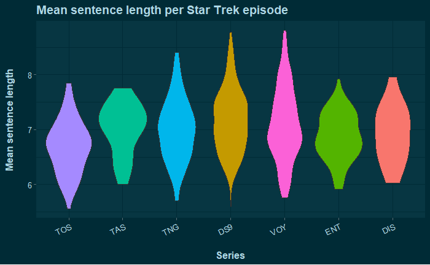

```r
st_sen_tbl %>% mutate(series = substr(name, 1, 3)) %>%
  group_by(series) %>%
  mutate(IQR = IQR(mean_sentence_length),
         q1 = quantile(mean_sentence_length,
                       probs = 0.25),
         q2 = quantile(mean_sentence_length,
                       probs = 0.75),
         qup = q2 + (1.5 * IQR),
         qlow = q1 -(1.5 * IQR)) %>%
  filter(mean_sentence_length >= qlow,
         mean_sentence_length <= qup) %>%
  ggplot(aes(
  x = factor(series,
             levels = c("TOS", "TAS", "TNG", "DS9",
                        "VOY", "ENT", "DIS")),
  y = mean_sentence_length)) +
  geom_violin(aes(fill = series)) +
  labs(x = "\nSeries", y = "Mean sentence length\n", fill = "",
       title = "Mean sentence length per Star Trek episode") +
  guides(fill = FALSE) +
  theme_solarized_dark(f_color = "lightblue", f_angle = 25)
```

Average word lengths

```r
word_lens <- c()
for(ep in seq(1, length(std_tags))) {
  std_des <- describe(std_tags[[ep]])
  word_lens[length(word_lens) + 1] <- std_des$avg.word.length
}
for(ep in seq(1, length(st_tags))) {
  st_des <- describe(st_tags[[ep]])
  word_lens[length(word_lens) + 1] <- st_des$avg.word.length
}
```

```r
st_word_tbl <-
  tibble("name" = c(st_names, std_names),
       "mean_word_length" = word_lens)
head(st_word_tbl)
```

| name | mean_word_length |
| --- | --- |
| ENT_episode 0 | 4.520557 |
| ENT_episode 1 | 4.429250 |
| ENT_episode 2 | 4.168379 |
| ENT_episode 3 | 4.290788 |
| ENT_episode 4 | 4.222074 |
| ENT_episode 5 | 4.092465 |

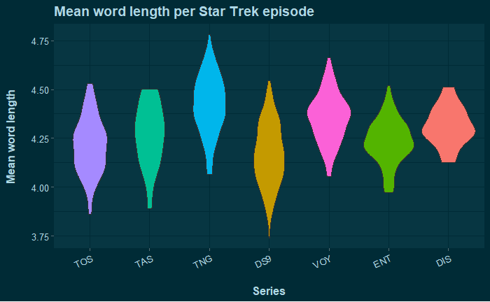

```r
st_word_tbl %>% mutate(series = substr(name, 1, 3)) %>%
  group_by(series) %>%
  mutate(IQR = IQR(mean_word_length),
         q1 = quantile(mean_word_length,
                       probs = 0.25),
         q2 = quantile(mean_word_length,
                       probs = 0.75),
         qup = q2 + (1.5 * IQR),
         qlow = q1 -(1.5 * IQR)) %>%
  filter(mean_word_length >= qlow,
         mean_word_length <= qup) %>%
  ggplot(aes(
  x = factor(series,
             levels = c("TOS", "TAS", "TNG", "DS9",
                        "VOY", "ENT", "DIS")),
  y = mean_word_length)) +
  geom_violin(aes(fill = series)) +
  labs(x = "\nSeries", y = "Mean word length\n", fill = "",
       title = "Mean word length per Star Trek episode") +
  guides(fill = FALSE) +
  theme_solarized_dark(f_color = "lightblue", f_angle = 25)
```

Lexical diversity - the ratio of different unique word stems (types) to the total number of words

```r
st_mtld_tbl <-
  tibble("name" = c(std_names, st_names),
       "mtld" = mtld)
head(st_mtld_tbl)
```

| name | mtld |
| --- | --- |
| DIS_101 | 135.76818 |
| DIS_102 | 115.89821 |
| DIS_103 | 93.53099 |
| DIS_104 | 132.21816 |
| DIS_105 | 99.66667 |
| DIS_106 | 99.61817 |

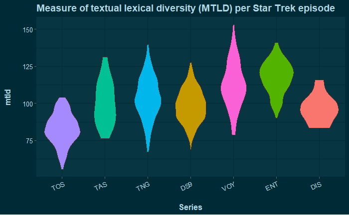

```r
st_mtld_tbl %>% mutate(series = substr(name, 1, 3)) %>%
  group_by(series) %>%
  mutate(IQR = IQR(mtld),
         q1 = quantile(mtld,
                       probs = 0.25),
         q2 = quantile(mtld,
                       probs = 0.75),
         qup = q2 + (1.5 * IQR),
         qlow = q1 -(1.5 * IQR)) %>%
  filter(mtld >= qlow,
         mtld <= qup) %>%
  ggplot(aes(
  x = factor(series,
             levels = c("TOS", "TAS", "TNG", "DS9",
                        "VOY", "ENT", "DIS")),
  y = mtld)) +
  geom_violin(aes(fill = series)) +
  labs(x = "\nSeries", y = "mtld\n", fill = "",
       title = "Measure of textual lexical diversity (MTLD) per Star Trek episode") +
  guides(fill = FALSE) +
  theme_solarized_dark(f_color = "lightblue", f_angle = 25)
```

Lexical diversity (very long running block)

```r
st_mtld_tbl <-
  tibble("name" = c(std_names, st_names),
       "mtldma" = mtldma)
head(st_mtld_tbl)
```

| name | mtldma |
| --- | --- |
| DIS_101 | 133.30163 |
| DIS_102 | 121.07132 |
| DIS_103 | 98.99744 |
| DIS_104 | 129.12917 |
| DIS_105 | 117.35352 |
| DIS_106 | 111.45724 |

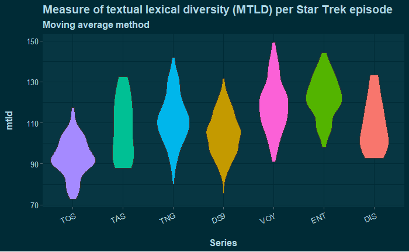

```r
st_mtld_tbl %>% mutate(series = substr(name, 1, 3)) %>%
  group_by(series) %>%
  mutate(IQR = IQR(mtldma),
         q1 = quantile(mtldma,
                       probs = 0.25),
         q2 = quantile(mtldma,
                       probs = 0.75),
         qup = q2 + (1.5 * IQR),
         qlow = q1 -(1.5 * IQR)) %>%
  filter(mtldma >= qlow,
         mtldma <= qup) %>%
  ggplot(aes(
  x = factor(series,
             levels = c("TOS", "TAS", "TNG", "DS9",
                        "VOY", "ENT", "DIS")),
  y = mtldma)) +
  geom_violin(aes(fill = series)) +
  labs(x = "\nSeries", y = "mtld\n", fill = "",
       title = "Measure of textual lexical diversity (MTLD) per Star Trek episode",
       subtitle = "Moving average method") +
  guides(fill = FALSE) +
  theme_solarized_dark(f_color = "lightblue", f_angle = 25)
```